# Inferential Statistics Demo

Joshua M. Garcia

3/2/2021

This line of code is to install the “jmv” package that is integrated with jamovi. “eval=FALSE” means that this line will not run unless you manually tell it to. This is to avoid reinstalling each time this code is ran.

I also install the tableone, tidyverse, and kableExtra packages for later on.

```r
install.packages('jmv')
install.packages('tableone')
install.packages('tidyverse')
install.packages('kableExtra')
install.packages('vcdExtra')
```

## Scientific notation

R will convert large numbers to scientific notation. You must command R to not do this to avoid computation errors down the line. This following chunk commands R to avoid scientific notation in output. For help see, [“Stack overflow: How to prevent scientific notation in R?”](https://stackoverflow.com/questions/25946047/how-to-prevent-scientific-notation-in-r/25946211)

```r
options(scipen=999)
```

# Import Data

“A data set giving the number of publications by doctoral candidates in biochemistry in relation to various predictors, originally from Long (1997).”

```r
library(tidyverse) #load additional functions
library(kableExtra)
library(broom)
library(vcdExtra) #load package with data set
data <- PhdPubs #assign data set to data frame titled "data"
```

"A data frame with 915 observations on the following 6 variables.

articles - number of articles published in the final three years of PhD studies

female - dummy variable for gender, coded 1 for female

married - dummy variable for marital status, coded 1 for married

kid5 - number of young children, age 5 and under

phdprestige - prestige of the PhD department

mentor - number of publications by the mentor in the preceeding three years"

This command is to view the top of the data.

```r
head(data)
```

```
##   articles female married kid5 phdprestige mentor
## 1        0      0       1    0           3      7
## 2        0      1       0    0           2      6
## 3        0      1       0    0           4      6
## 4        0      0       1    1           1      3
## 5        0      1       0    0           4     26
## 6        0      1       1    2           4      2
```

# Correlations

```r
pwr::pwr.r.test(n = 915, sig.level = 0.05, power = 0.8)
```

```
##
##      approximate correlation power calculation (arctangh transformation)
##
##               n = 915
##               r = 0.09247308
##       sig.level = 0.05
##           power = 0.8
##     alternative = two.sided
```

Data are sufficient to detect effects of 0.092 and above with >80% power, this includes small effects and above.

```r
jmv::corrMatrix(
    data = data,
    vars = vars(female, married, mentor, articles, kid5, phdprestige))
```

```
##
##  CORRELATION MATRIX
##
##  Correlation Matrix
##  -------------------------------------------------------------------------------------------------------------------
##                                  female        married       mentor        articles      kid5          phdprestige
##  -------------------------------------------------------------------------------------------------------------------
##    female         Pearson's r             —
##                   p-value                 —
##
##    married        Pearson's r    -0.2495715             —
##                   p-value        < .0000001             —
##
##    mentor         Pearson's r    -0.0874447     0.0036738             —
##                   p-value         0.0081314     0.9116347             —
##
##    articles       Pearson's r    -0.1067441     0.0373404     0.3058616             —
##                   p-value         0.0012219     0.2591686    < .0000001             —
##
##    kid5           Pearson's r    -0.2966771     0.4624493     0.0370203    -0.0452145             —
##                   p-value        < .0000001    < .0000001     0.2632770     0.1717758             —
##
##    phdprestige    Pearson's r    -0.0242340    -0.0605584     0.2772295     0.0910951    -0.0164100              —
##                   p-value         0.4640710     0.0670999    < .0000001     0.0058245     0.6200779              —
##  -------------------------------------------------------------------------------------------------------------------
```

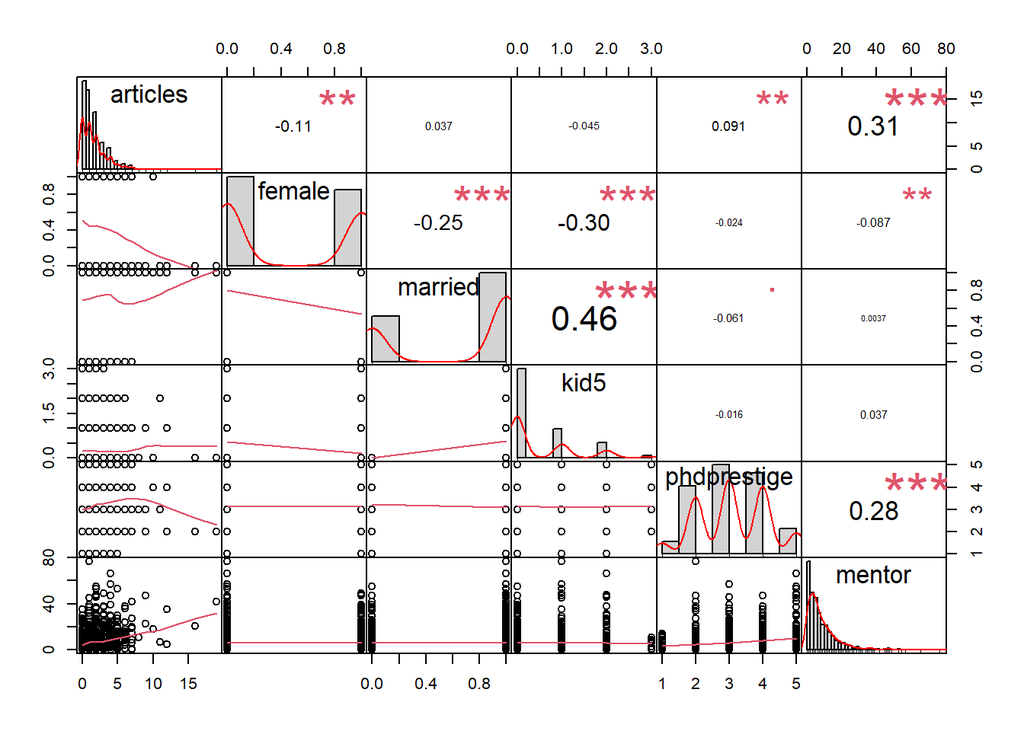

```r
PerformanceAnalytics::chart.Correlation(data, histogram=TRUE)
```

The threshold for plotting a network path is the smallest significant correlation (r = 0.087)

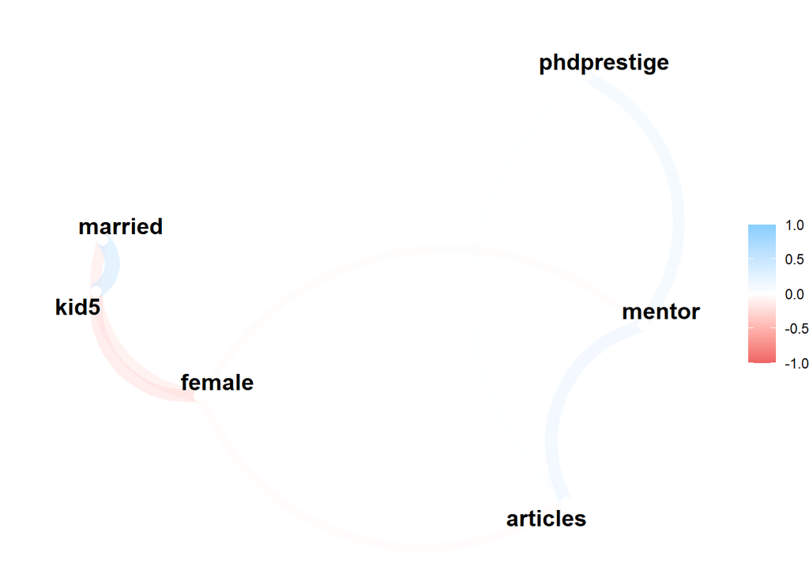

```r
library(corrr)
data %>% correlate() %>% network_plot(min_cor=0.086)
```

# T-tests

```r
pwr::pwr.t.test(n = 457, power = 0.80, sig.level = 0.05)
```

```
##
##      Two-sample t test power calculation
##
##               n = 457
##               d = 0.1855337
##       sig.level = 0.05
##           power = 0.8
##     alternative = two.sided
##
## NOTE: n is number in *each* group
```

Effect sizes of d = 0.1855337 and above have >80% power, this indicates sufficient power for small effects (d=0.2) and above.

```
##
##  INDEPENDENT SAMPLES T-TEST
##
##  Independent Samples T-Test
##  ---------------------------------------------------------------------------------
##                                  Statistic    df          p            Cohen's d
##  ---------------------------------------------------------------------------------
##    articles    Student's t        3.243901    913.0000    0.0012219    0.2151660
##                Welch's t          3.329833    885.9453    0.0009049    0.2151660
##                Mann-Whitney U     94480.50                0.0141103    0.2151660
##  ---------------------------------------------------------------------------------
```

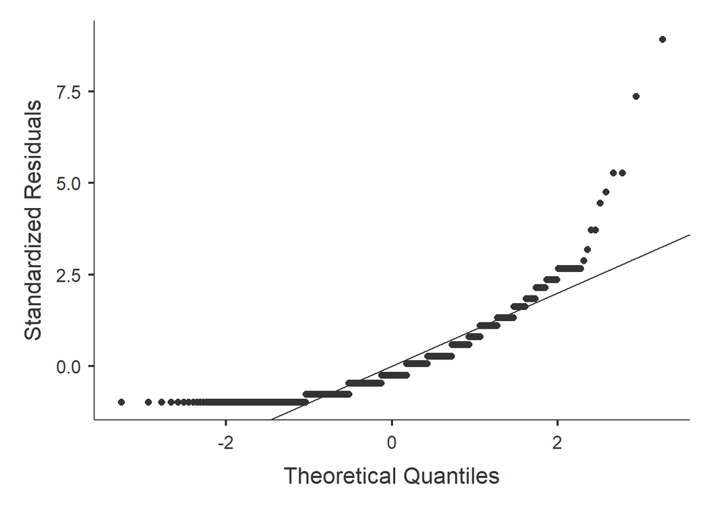

```r
jmv::ttestIS(
    formula = articles ~ female,
    data = data,
    vars = articles,
    welchs = TRUE,
    mann = TRUE,
    qq = TRUE,
    ci = TRUE,
    effectSize = TRUE)
```

```r
jmv::descriptives(
    formula = articles ~ female,
    data = data,
    missing = FALSE)
```

```
##
##  DESCRIPTIVES
##
##  Descriptives
##  ---------------------------------
##               female    articles
##  ---------------------------------
##    N          0              494
##               1              421
##    Mean       0         1.882591
##               1         1.470309
##    Median     0         1.000000
##               1                1
##    Minimum    0                0
##               1                0
##    Maximum    0               19
##               1               10
##  ---------------------------------
```

```
##
##  INDEPENDENT SAMPLES T-TEST
##
##  Independent Samples T-Test
##  -----------------------------------------------------------------------------------
##                                  Statistic    df          p            Cohen's d
##  -----------------------------------------------------------------------------------
##    articles    Student's t       -1.129061    913.0000    0.2591686    -0.07892462
##                Welch's t         -1.186940    710.3068    0.2356480    -0.07892462
##                Mann-Whitney U     89634.00                0.2773028    -0.07892462
##  -----------------------------------------------------------------------------------
```

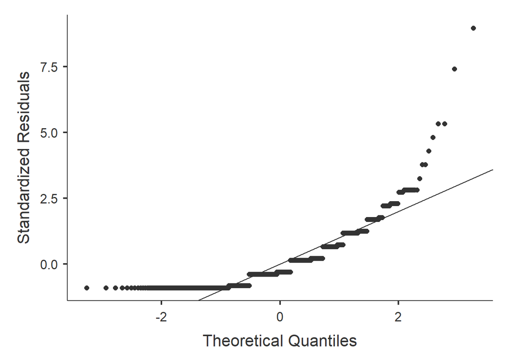

```r
jmv::ttestIS(
    formula = articles ~ married,
    data = data,
    vars = articles,
    welchs = TRUE,
    mann = TRUE,
    qq = TRUE,
    ci = TRUE,
    effectSize = TRUE)
```

```r
jmv::descriptives(
    formula = articles ~ married,
    data = data,
    missing = FALSE)
```

```
##
##  DESCRIPTIVES
##
##  Descriptives
##  ----------------------------------
##               married    articles
##  ----------------------------------
##    N          0               309
##               1               606
##    Mean       0          1.592233
##               1          1.744224
##    Median     0                 1
##               1          1.000000
##    Minimum    0                 0
##               1                 0
##    Maximum    0                 7
##               1                19
##  ----------------------------------
```

```r
ttest_female <- psych::cohen.d(data ~ female)

ttest_female_table <- cbind(ttest_female[["t"]], ttest_female[["p"]]) %>%
  cbind(ttest_female[["cohen.d"]]) %>% round(3)

colnames(ttest_female_table) = c("t","p","lower d", "estimated d", "upper d")

ttest_female_table %>%  kable(caption = "Cohen's d of data by female") %>%
   kable_styling(c("bordered","condensed"),
                latex_options = c("HOLD_position"),
                font_size = 10,
                full_width = F)
```

Cohen’s d of data by female

|  | t | p | lower d | estimated d | upper d |
| --- | --- | --- | --- | --- | --- |
| articles | -3.258 | 0.001 | -0.346 | -0.215 | -0.085 |
| married | -7.821 | 0.000 | -0.651 | -0.517 | -0.383 |
| kid5 | -9.427 | 0.000 | -0.759 | -0.623 | -0.487 |
| phdprestige | -0.736 | 0.462 | -0.179 | -0.049 | 0.081 |
| mentor | -2.664 | 0.008 | -0.307 | -0.176 | -0.046 |

```r
ttest_married <- psych::cohen.d(data ~ married)

ttest_married_table <- cbind(ttest_married[["t"]], ttest_married[["p"]]) %>%
  cbind(ttest_married[["cohen.d"]]) %>% round(3)

colnames(ttest_married_table) = c("t","p","lower d", "estimated d", "upper d")

ttest_married_table %>%  kable(caption = "Cohen's d of data by married") %>%
   kable_styling(c("bordered","condensed"),
                latex_options = c("HOLD_position"),
                font_size = 10,
                full_width = F)
```

Cohen’s d of data by married

|  | t | p | lower d | estimated d | upper d |
| --- | --- | --- | --- | --- | --- |
| articles | 1.195 | 0.232 | -0.058 | 0.079 | 0.216 |
| female | -8.242 | 0.000 | -0.688 | -0.545 | -0.401 |
| kid5 | 16.680 | 0.000 | 0.940 | 1.103 | 1.265 |
| phdprestige | -1.940 | 0.053 | -0.266 | -0.128 | 0.009 |
| mentor | 0.117 | 0.906 | -0.129 | 0.008 | 0.145 |

# Linear Regression

```r
pwr::pwr.f2.test(u = 5, v=915, sig.level = 0.05, power = 0.8)
```

```
##
##      Multiple regression power calculation
##
##               u = 5
##               v = 915
##              f2 = 0.01399133
##       sig.level = 0.05
##           power = 0.8
```

The power analysis suggests that an f2 value of 0.01399133 is necessary to have 80% power at the 0.05 significance level, with 5 predictors. This means that the model must explain at least 1.4% of the variance to have 80% power (an 80% chance of avoiding a type 2 error “false negative”).

```r
pwr::pwr.f2.test(u = 5, v=40, sig.level = 0.05, power = 0.8)
```

```
##
##      Multiple regression power calculation
##
##               u = 5
##               v = 40
##              f2 = 0.3196103
##       sig.level = 0.05
##           power = 0.8
```

For a hypothetical comparison, if we were to estimate the same model with only 40 participants, the f2 value would have to equal 0.3196103 to have 80% power.

```
##
##  LINEAR REGRESSION
##
##  Model Fit Measures
##  ------------------------------------------------------------------------------------------
##    Model    R            R²           Adjusted R²    F           df1    df2    p
##  ------------------------------------------------------------------------------------------
##        1    0.3322469    0.1103880      0.1054947    22.55876      5    909    < .0000001
##  ------------------------------------------------------------------------------------------
##
##
##  MODEL SPECIFIC RESULTS
##
##  MODEL 1
##
##  Model Coefficients - articles
##  ---------------------------------------------------------------------------------------------------------
##    Predictor        Estimate       SE             Lower          Upper          t             p
##  ---------------------------------------------------------------------------------------------------------
##    Intercept   ᵃ     1.25628311    0.232492633     0.79999838     1.71256784     5.4035394    < .0000001
##    phdprestige       0.01463409    0.060716755    -0.10452722     0.13379541     0.2410223     0.8095922
##    mentor            0.06074867    0.006637487     0.04772209     0.07377525     9.1523605    < .0000001
##    kid5             -0.29136884    0.090917746    -0.46980193    -0.11293575    -3.2047521     0.0013989
##    married:
##    1 – 0             0.26737151    0.145206322    -0.01760710     0.55235012     1.8413214     0.0659002
##    female:
##    1 – 0            -0.37978876    0.128112249    -0.63121893    -0.12835858    -2.9644999     0.0031109
##  ---------------------------------------------------------------------------------------------------------
##    ᵃ Represents reference level
##
##
##  ASSUMPTION CHECKS
##
##  Collinearity Statistics
##  ----------------------------------------
##                   VIF         Tolerance
##  ----------------------------------------
##    phdprestige    1.088024    0.9190973
##    mentor         1.091446    0.9162156
##    kid5           1.331998    0.7507519
##    married        1.300333    0.7690340
##    female         1.124198    0.8895233
##  ----------------------------------------
```

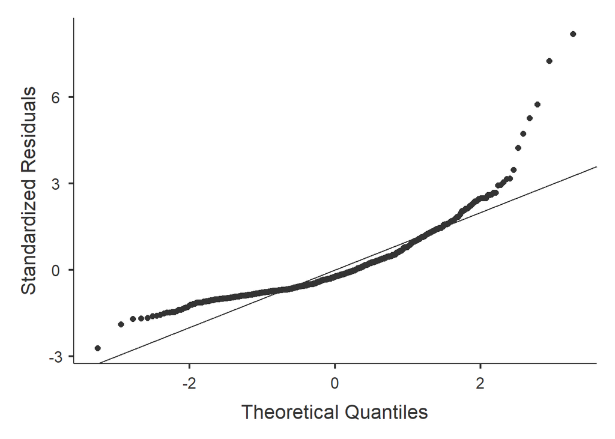

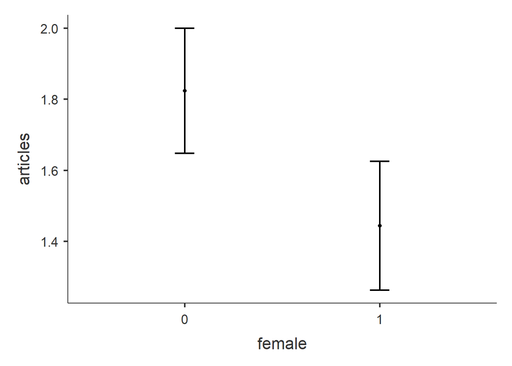

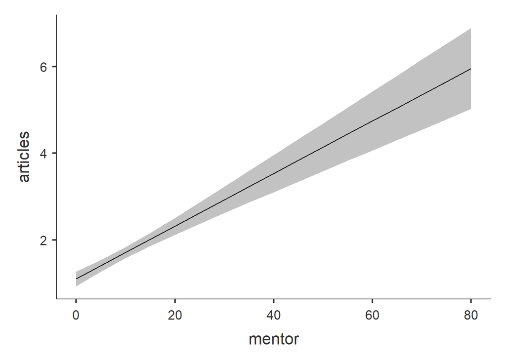

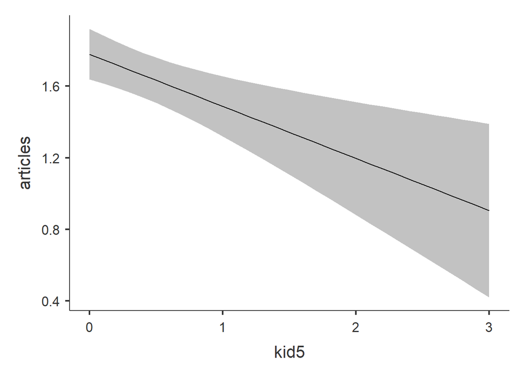

```r
jmv::linReg(
    data = data,
    dep = articles,
    covs = vars(phdprestige, mentor, kid5),
    factors = vars(married, female),
    blocks = list(
        list(
            "phdprestige",
            "mentor",
            "kid5",
            "married",
            "female")),
    refLevels = list(
        list(
            var="married",
            ref="0"),
        list(
            var="female",
            ref="0")),
    r2Adj = TRUE,
    modelTest = TRUE,
    ci = TRUE,
    ciStdEst = TRUE,
    qqPlot = TRUE,
    collin = TRUE,
    emMeans = ~ female + mentor + kid5)
```

# Comparison to Base R and ggeffects

```r
data$gender <- factor(data$female,
                             levels = c(0,1),
                             labels = c("Male","Female"))

data$married <- factor(data$married,
                             levels = c(0,1),
                             labels = c("Single","Married"))
```

```r
fit <- lm(articles ~ phdprestige + mentor + kid5 + married + gender, data)

summary(fit)
```

```
##
## Call:
## lm(formula = articles ~ phdprestige + mentor + kid5 + married +
##     gender, data = data)
##
## Residuals:
##     Min      1Q  Median      3Q     Max
## -4.9392 -1.2388 -0.4210  0.7382 14.8956
##
## Coefficients:
##                 Estimate Std. Error t value             Pr(>|t|)
## (Intercept)     1.256283   0.232493   5.404         0.0000000835 ***
## phdprestige     0.014634   0.060717   0.241              0.80959
## mentor          0.060749   0.006637   9.152 < 0.0000000000000002 ***
## kid5           -0.291369   0.090918  -3.205              0.00140 **
## marriedMarried  0.267372   0.145206   1.841              0.06590 .
## genderFemale   -0.379789   0.128112  -2.964              0.00311 **
## ---
## Signif. codes:  0 '***' 0.001 '**' 0.01 '*' 0.05 '.' 0.1 ' ' 1
##
## Residual standard error: 1.822 on 909 degrees of freedom
## Multiple R-squared:  0.1104, Adjusted R-squared:  0.1055
## F-statistic: 22.56 on 5 and 909 DF,  p-value: < 0.00000000000000022
```

```r
tidy(fit)
```

```
## # A tibble: 6 x 5
##   term           estimate std.error statistic  p.value
##   <chr>             <dbl>     <dbl>     <dbl>    <dbl>
## 1 (Intercept)      1.26     0.232       5.40  8.35e- 8
## 2 phdprestige      0.0146   0.0607      0.241 8.10e- 1
## 3 mentor           0.0607   0.00664     9.15  3.59e-19
## 4 kid5            -0.291    0.0909     -3.20  1.40e- 3
## 5 marriedMarried   0.267    0.145       1.84  6.59e- 2
## 6 genderFemale    -0.380    0.128      -2.96  3.11e- 3
```

```r
fit_f2 <- summary(fit)[["adj.r.squared"]] / (1 - summary(fit)[["adj.r.squared"]])

round(fit_f2,2)
```

```
## [1] 0.12
```

The f2 value calculated from the adjusted r2 value indicated a small effect size for the proportion of explained variance.

QQ-plot to check for normality of residuals.

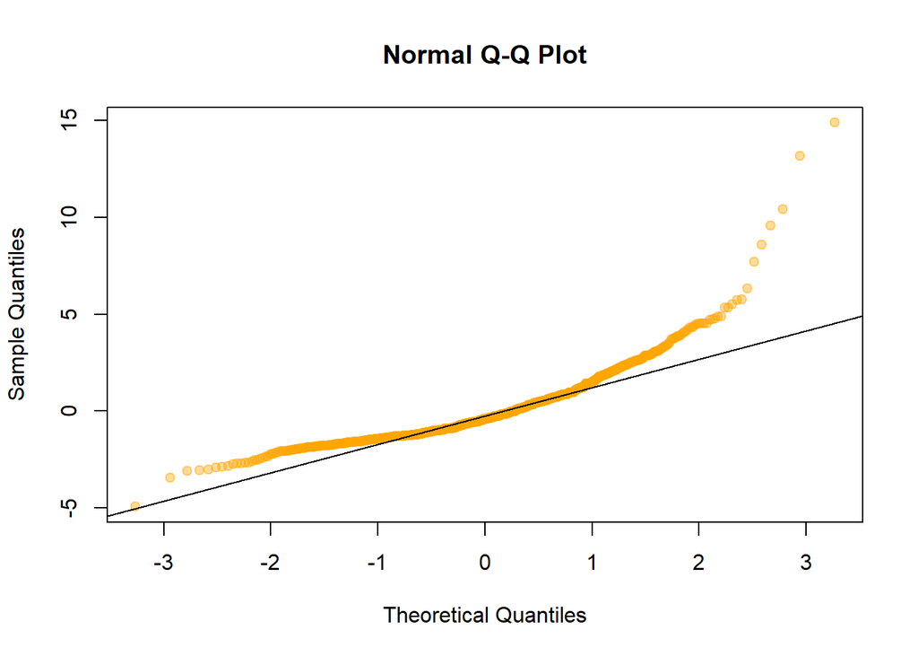

```r
dat <- resid(fit)
qqnorm(dat, col=adjustcolor("orange", 0.4), pch=19)
qqline(dat)
```

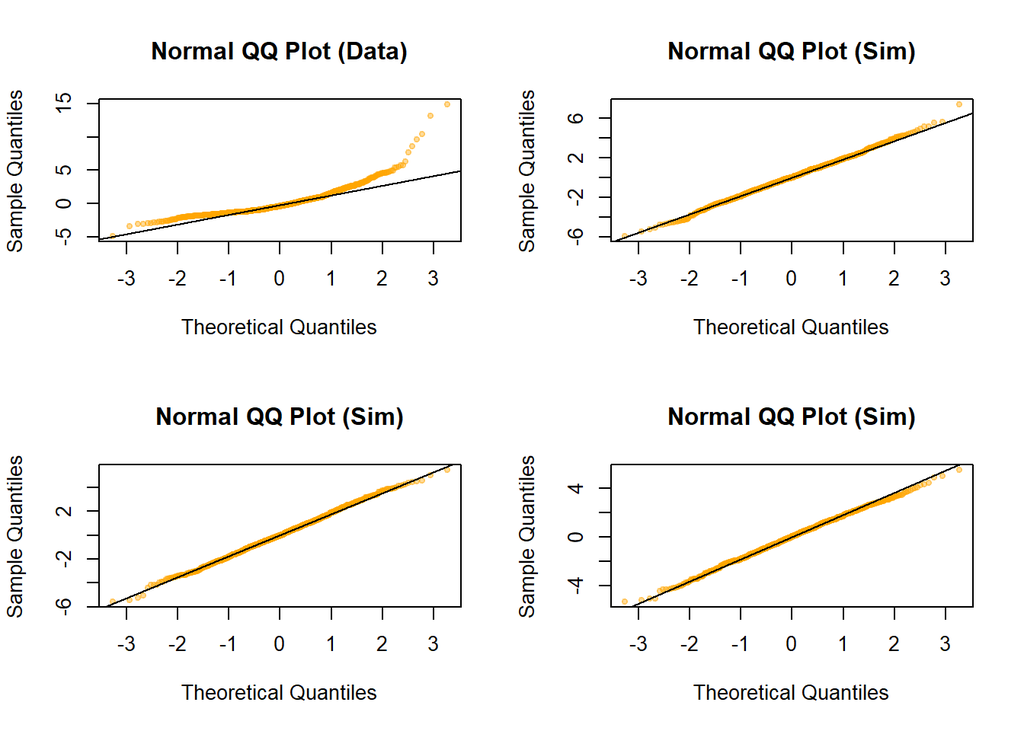

```r
qqnormsim = function(dat, dim=c(2,2)) {
  par(mfrow=dim)
  qqnorm(dat, col=adjustcolor("orange", 0.4),
         pch=19, cex=0.7, main="Normal QQ Plot (Data)")
  qqline(dat)
  for (i in 1:(prod(dim) - 1)) {
    simnorm = rnorm(n=length(dat), mean=mean(dat), sd=sd(dat))
    qqnorm(simnorm, col=adjustcolor("orange", 0.4),
           pch=19, cex=0.7,
           main="Normal QQ Plot (Sim)")
    qqline(simnorm)
  }
  par(mfrow=c(1, 1))
}
qqnormsim(resid(fit))
```

This qq-plot reflects a heavy right skew, which can potentially threaten the generalizability of these results, since the residuals are non-normal in the upper quantiles. However, in a larger data set (n=915), the impact of the violation of this assumption is less severe than if the data set were small. [See here for more information.](https://www.quality-control-plan.com/StatGuide/linreg_ass_viol.htm)

```r
car::vif(fit)
```

```
## phdprestige      mentor        kid5     married      gender
##    1.088024    1.091446    1.331998    1.300333    1.124198
```

Variance inflation factors are all <4, indicating a lack of problematic multicollinearity.

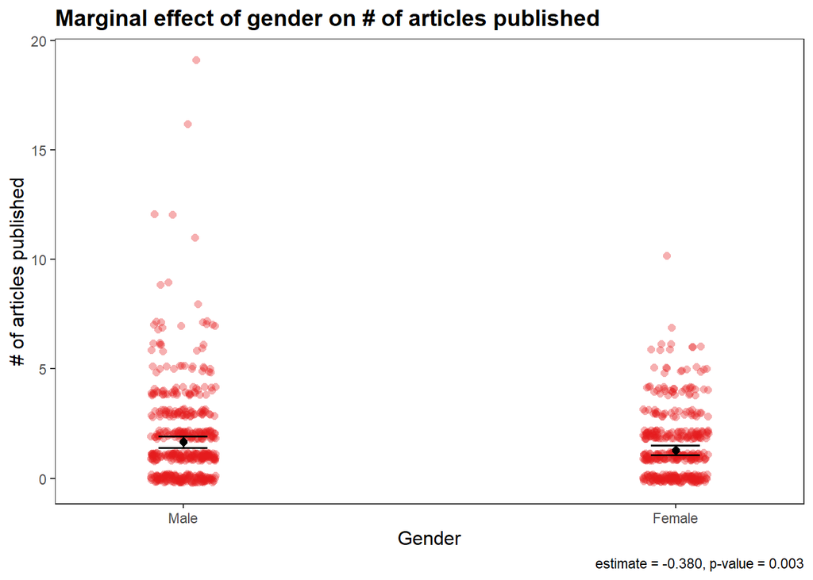

```r
library(ggeffects)
library(jtools)

effect_gender <- ggpredict(fit, terms = c("gender"))

plot(effect_gender, add.data = TRUE) +
  theme_apa() +
  labs(
    x = "Gender",
    y = "# of articles published",
    title = "Marginal effect of gender on # of articles published",
    caption = "estimate = -0.380, p-value = 0.003")
```

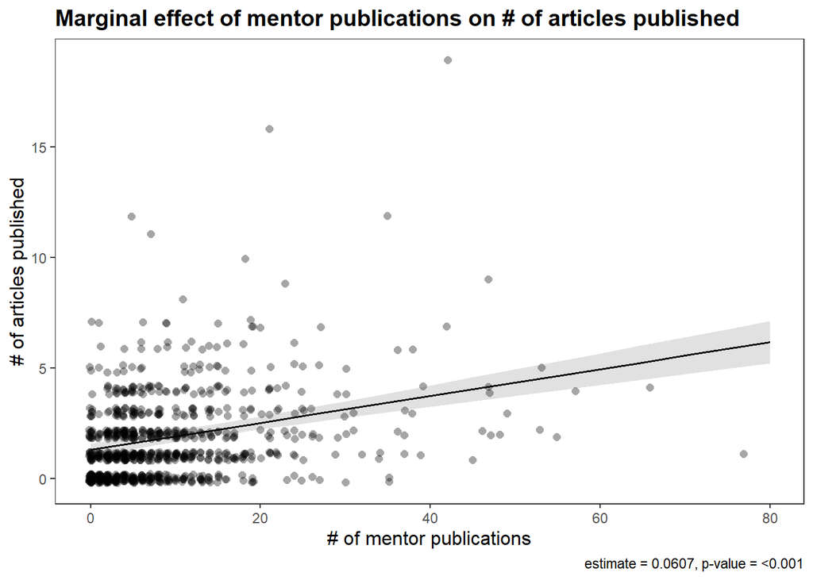

```r
effect_mentor <- ggpredict(fit, terms = c("mentor"))

plot(effect_mentor, add.data = TRUE) +
  theme_apa() +
  labs(
    x = "# of mentor publications",
    y = "# of articles published",
    title = "Marginal effect of mentor publications on # of articles published",
    caption = "estimate = 0.0607, p-value = <0.001")
```

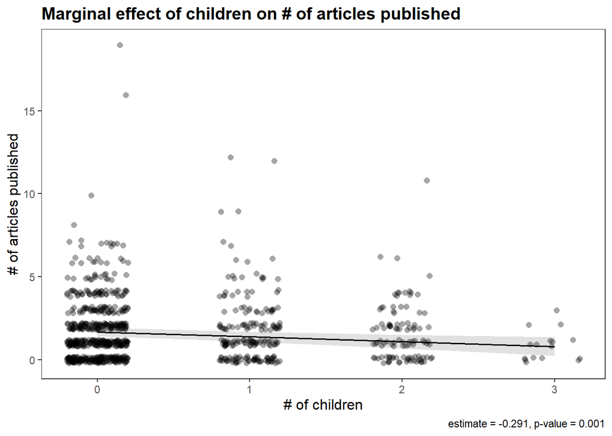

```r
effect_kid5 <- ggpredict(fit, terms = c("kid5"))

plot(effect_kid5, add.data = TRUE) +
  theme_apa() +
  labs(
    x = "# of children",
    y = "# of articles published",
    title = "Marginal effect of children on # of articles published",
    caption = "estimate = -0.291, p-value = 0.001")
```